# RStudio Exercise 2: Tasks and Instructions

*Describe the work you have done this week and summarize your learning.*

I started this week with learning R through the Data Camp platform. I learned how to handle (wrangle) data in R. I learned how to modify existing datasets, merge different datasets, and carry out simple and multiple linear regressin analyses. I also learned how to make graphical representations of these analyses.

### Dataset

The dataset given to us was from the “International survey of Approaches to Learning” funded by the Teacher’s Academy funding for Kimma Vehkalahti. Data was collected during 2013-2015

Oridinal dataset had 183 observations for 60 variables. Variables with prefix A adn C were based on componenets of A and C parts of [ASSIST](http://www.etl.tla.ed.ac.uk/publications.html#measurement) (Approaches and Study Skills Inventory for Students). Prefix D variables were based on [SATS](http://www.evaluationandstatistics.com/) (Survey of Attitudes Toward Statistics). Items from the ASSIST B part were named so that their connection to the relevant dimension (Deep/Surface/Strategic) was maintained

### Data wrangling

The dataset had multiple variables and I was supposed to merge assist B components into three major variables (Deep, Surface, Strategy). I also renamed three other variables (Age Attitude, Points -> age, attitude, points). Then I had to exclude other variables after selecting only 7 variables. The resulting dataset I saved as lrn2014.csv which has **7 variables** and **166 observations** for each variable.

### Data distribution

Gender distribution was uneven, there were 110 female and 56 male subjects.

**Distributions of each variable (except gender) are given below:**

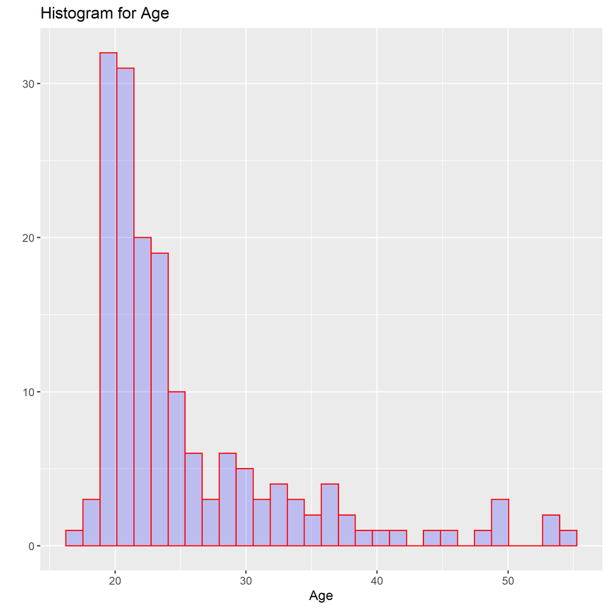

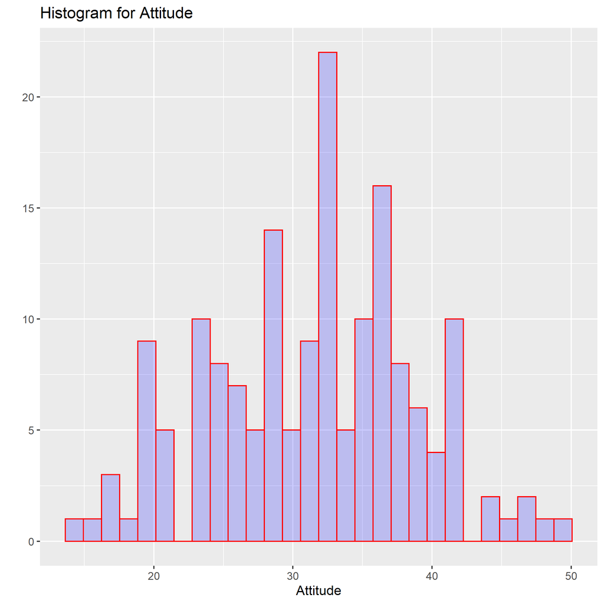

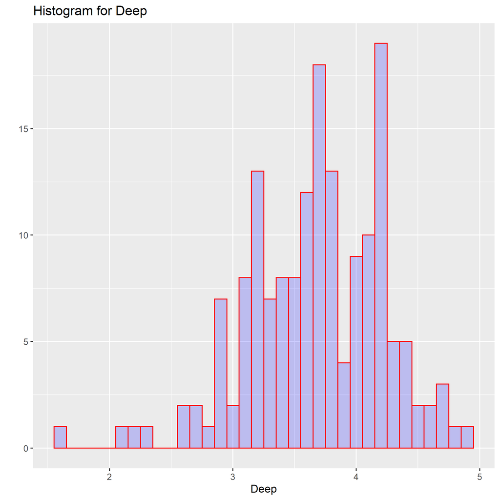

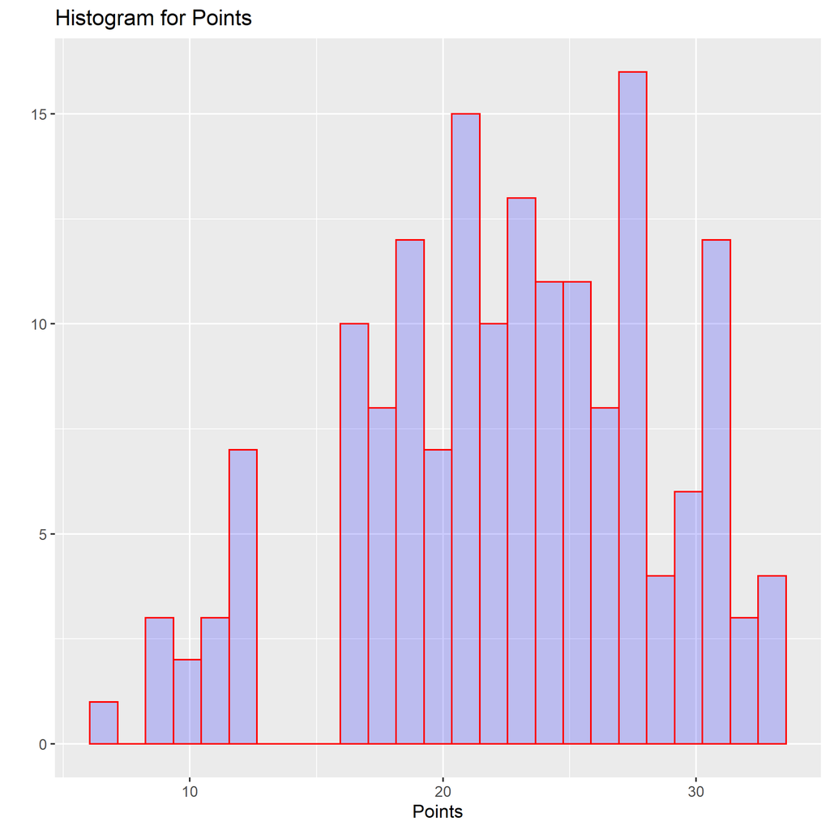

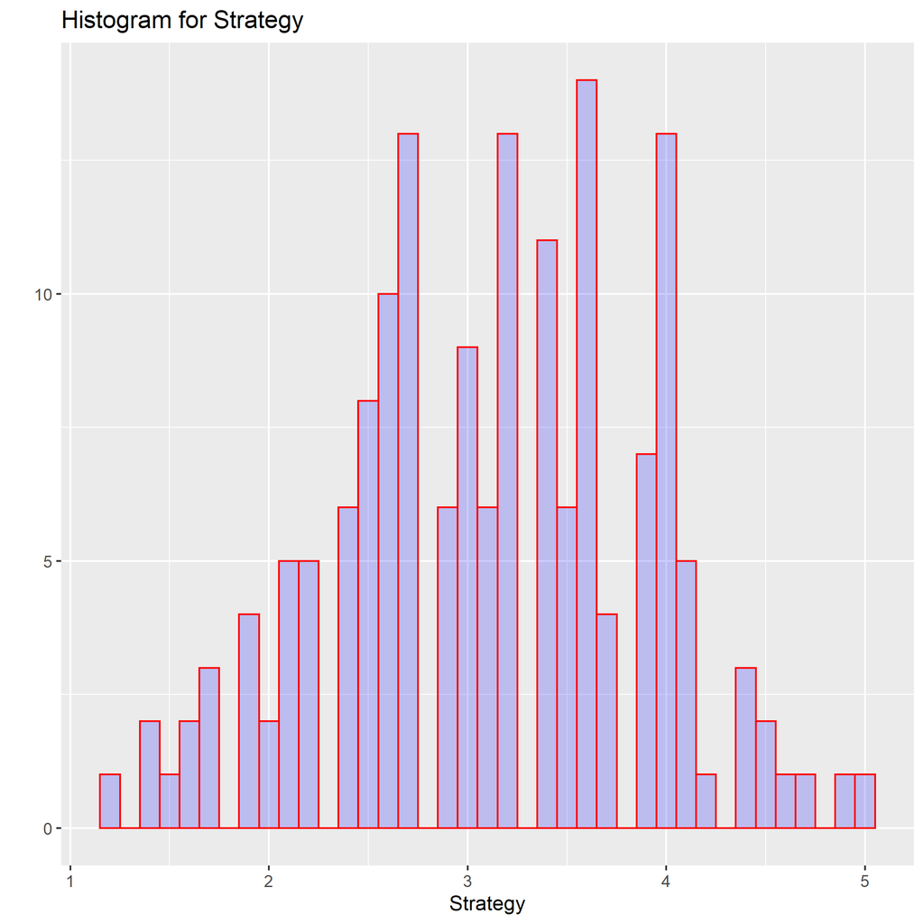

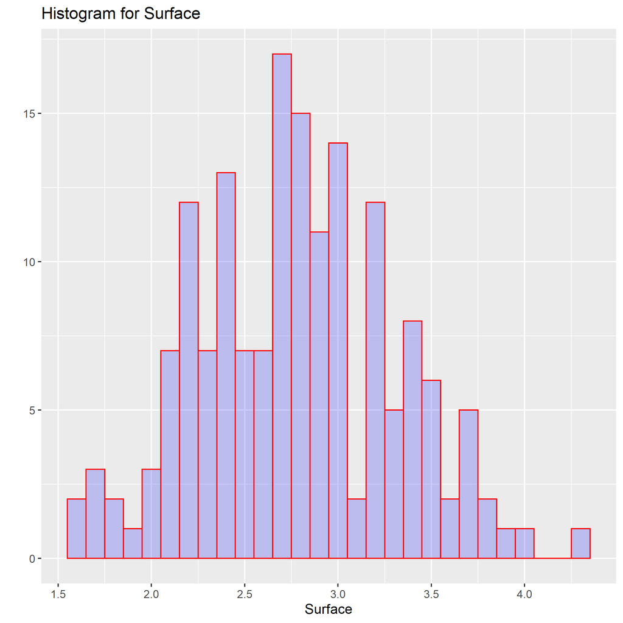

**Following is a summary table for all variables:**

[output not shown]

### Regression

I first carried out an exploratory analysis to find out which variables correlate best with points:

[figure not shown]

Attitude, strategy and surface had the strongest corellation and therefore were chosen as the predictor variables

I ran a multiple linear regression model and got following results

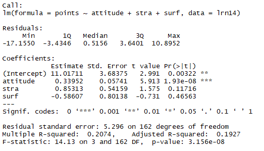

According to the results, attitude is the only variable that has significant linear relationship with points (p < 0.001). Each 1 point increase in attitude results in an increase of 0.34 in points.

Non-significant variables were removed and model was fitted again.

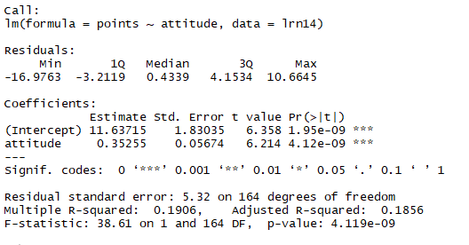

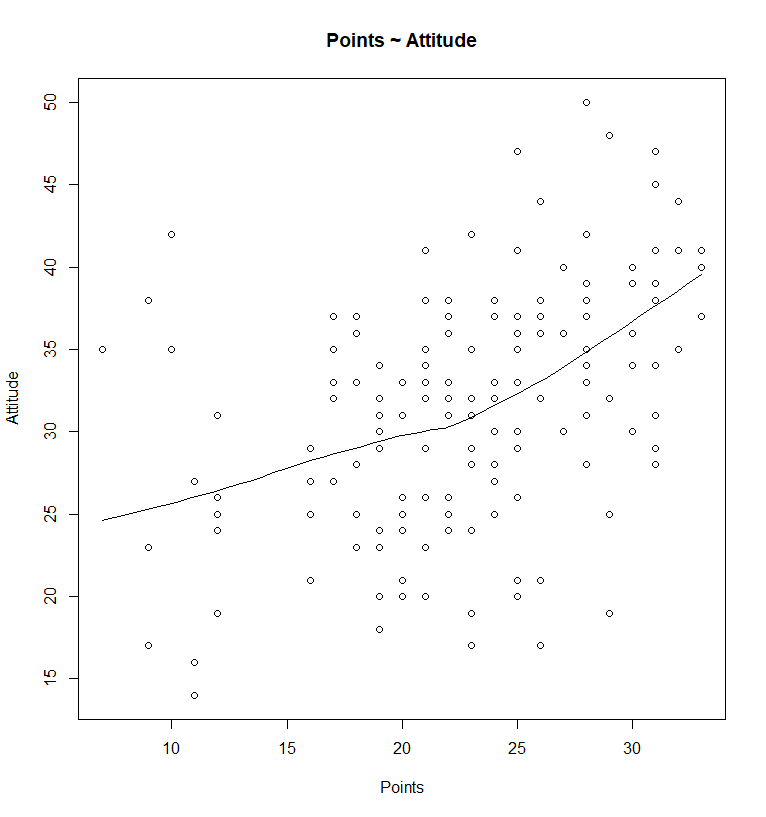

According to the final model, attitude has still a significant linear relationship with points, and each 1 point increase in attitude results in an increase of 0.35 in points. Multiple R-squared value is 0.19 which means that attitude explains 19 percent of variance in points.

Assumptions of the multiple linear model are that the

Errors are normally distributed Errors are not correlated Errors have constant variance The size of a given error does ot depend oin the explanatory variables

Diagnostic plots were created to check these assumptions

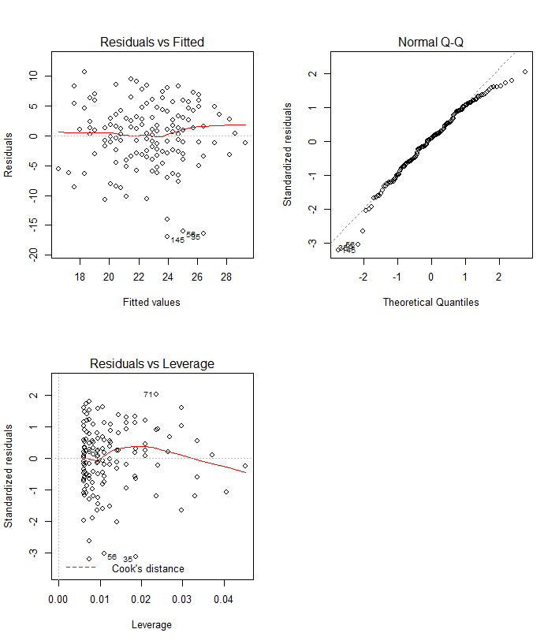

QQ-plot demostrates that the errors of the model are normally distributed, there are howeevr values at extremities that deviate from the normal line.

The scatterplot of residuals vs the fitted values shows no pattern, i.e. the spread remains largely similar with the increase in fitted value. Howeverthere are some residuals that are far form the fitted line. These could potentially be outliers

The residuals vs leverage plot shows that none of the eobservations have an unusually high impact on the results.